# The Project

1. This is a project with minimal scaffolding. Expect to use the the discussion forums to gain insights! It’s not cheating to ask others for opinions or perspectives!
2. Be inquisitive, try out new things.
3. Use the previous modules for insights into how to complete the functions! You'll have to combine Pillow, OpenCV, and Pytesseract
4. There are hints provided in Coursera, feel free to explore the hints if needed. Each hint provide progressively more details on how to solve the issue. This project is intended to be comprehensive and difficult if you do it without the hints.

### The Assignment

Take a ZIP file) of images and process them, using a [library built into python](https://docs.python.org/3/library/zipfile.html) that you need to learn how to use. A ZIP file takes several different files and compresses them, thus saving space, into one single file. The files in the ZIP file we provide are newspaper images (like you saw in week 3). Your task is to write python code which allows one to search through the images looking for the occurrences of keywords and faces. E.g. if you search for "pizza" it will return a contact sheet of all of the faces which were located on the newspaper page which mentions "pizza". This will test your ability to learn a new ([library](https://docs.python.org/3/library/zipfile.html)), your ability to use OpenCV to detect faces, your ability to use tesseract to do optical character recognition, and your ability to use PIL to composite images together into contact sheets.

Each page of the newspapers is saved as a single PNG image in a file called images.zip. These newspapers are in english, and contain a variety of stories, advertisements and images. Note: This file is fairly large (~200 MB) and may take some time to work with, I would encourage you to use small_img.zip for testing.

Here's an example of the output expected. Using the small_img.zip file, if I search for the string "Christopher" I should see the following image:

[figure not shown]

If I were to use the images.zip file and search for "Mark" I should see the following image (note that there are times when there are no faces on a page, but a word is found!):

[figure not shown]

Note: That big file can take some time to process - for me it took nearly ten minutes! Use the small one for testing.

```
Searching readonly/small_img.zip for Christopher

Christopher found in a-0.png
```

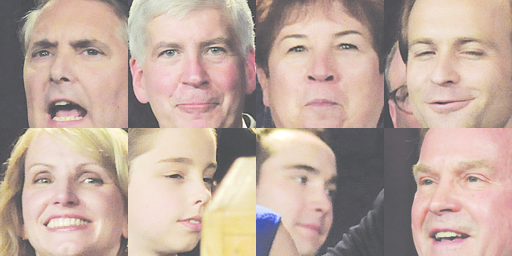

```
Christopher not in a-1.png
Christopher not in a-2.png
Christopher found in a-3.png
```

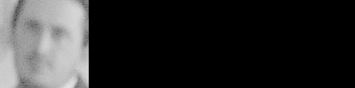

```
Searching readonly/images.zip for Mark

Mark found in a-0.png
```

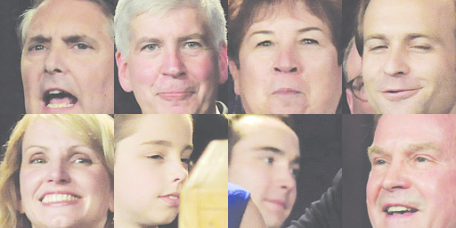

```
Mark found in a-1.png
```

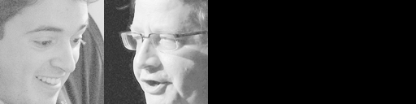

```
Mark found in a-10.png
```

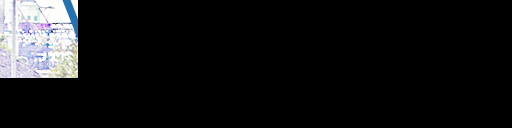

```
Mark not in a-11.png
Mark not in a-12.png
Mark found in a-13.png
```

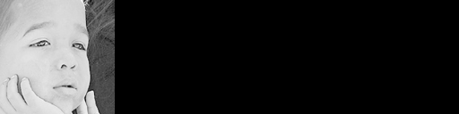

```
Mark found in a-2.png
```

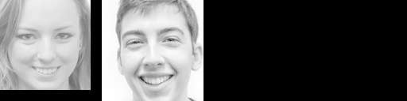

```
Mark found in a-3.png
```

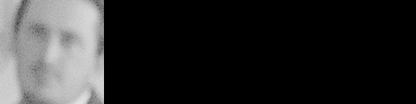

```
Mark not in a-4.png
Mark not in a-5.png
Mark not in a-6.png
Mark not in a-7.png
Mark found in a-8.png
```

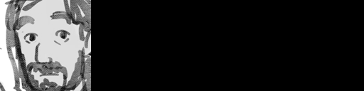

```
Mark not in a-9.png
```

```python
import zipfile
import PIL
import pytesseract
import cv2 as cv
import numpy as np
import zipfile
import PIL
import pytesseract
import cv2 as cv
import numpy as np
from kraken import pageseg
from PIL import Image, ImageDraw

# loading the face detection classifier
face_cascade = cv.CascadeClassifier('readonly/haarcascade_frontalface_default.xml')


def unzip_file(filename):
    ''' Function built to unzip .zip image files and return them as a dictionary of PIL images with filename as their key'''
    output_dict = {}
    with zipfile.ZipFile(filename) as z_f:
        for item in z_f.infolist():
            with z_f.open(item.filename, 'r') as image_f:
                img = Image.open(image_f)
                o_img = img.copy()
                output_dict[item.filename] = {'image':o_img}
    return output_dict


def find_text(txt_image):
    '''converts image to 'L' then uses pytesseract to convert the text to a string which out outputs'''
    ocr_image = txt_image.copy()
    ocr_image = ocr_image.convert('L')
    out_text = pytesseract.image_to_string(ocr_image)
    return(out_text)


def name_check(image, name):
    '''Checks and image for a given name'''
    page_text = find_text(image)
    if name in page_text:
        return True
    else:
        return False


def selective_face_check(i_dict, name):
    '''Iterates through a dictionary of images and searches for a given name.
    If that name is found, it displays any face it detects in the image'''
    for key in i_dict:
        image = i_dict[key]['image']
        if name_check(image, name):
            faces_lst = get_faces(image)
            print('{} found in {}'.format(name, key))
            face_thumbs = face_scrape(image, faces_lst)
            #for face in face_thumbs:
            #    display(face)
            if len(face_thumbs) > 0:
                composite_stitch(face_thumbs)
            else:
                print('{} found in {}, but no faces were found'.format(name, key))
        else:
            print('{} not in {}'.format(name, key))


def get_faces(image):
    '''Takes a given image and returns the coordinates of all faces in the image'''
    #convert to grayscale numpy array to switch to opencv image
    gray_image = image.copy()
    gray_image = gray_image.convert('L')
    numpy_image = np.array(image)
    bin_image = cv.threshold(numpy_image, 185, 255, cv.THRESH_BINARY)[1]
    #bin_image = numpy_image
    faces = face_cascade.detectMultiScale(bin_image,1.1, minNeighbors=10, minSize=(75,75))
    faces.tolist()
    #drw = ImageDraw.Draw(image)
    #for x,y,w,h in faces:
    #    drw.rectangle((x,y,x+w,y+h), outline = 'red')
    #display(image)
    return faces


def face_scrape(image, coord_lst):
    '''Takes an image and a list of coordinates (x,y,w,h) and returns a list of thumbnail images of each face'''
    outlist = []
    for x,y,w,h in coord_lst:
        temp_img = image.copy()
        #drw = ImageDraw.Draw(temp_img)
        #drw.rectangle((x,y,x+w,y+h), outline = 'red')
        temp_img = temp_img.crop((x,y,x+w,y+h))
        temp_img = temp_img.convert('RGB')
        #temp_img = gray2RGB(temp_img)
        temp_img.thumbnail((128,128))
        outlist.append(temp_img)
    return outlist


def composite_stitch(thumb_lst):
    '''Stitch together our face thumbnails into one image'''
    out_w = 4*128
    if len(thumb_lst)%4 == 0:
        out_h = (len(thumb_lst)//4) *128
    else:
        out_h = ((len(thumb_lst)//4) + 1) * 128

    out_img = Image.new('RGB', (out_w, out_h), color = 'black')
    x_p, y_p = 0, 0
    for thmb in thumb_lst:
        out_img.paste(thmb, (x_p,y_p))
        x_p += 128
        if x_p >= 128*4:
            x_p = 0
            y_p += 128

    display(out_img)


def project_search(file, name):
    '''The culmination of this project, pass in a .zip file and a name
    and a contact sheet with the faces on associated pages will be displayed'''
    print('Searching {} for {}\n'.format(file, name))
    img_dict = unzip_file(file)
    selective_face_check(img_dict, name)


def main():

    project_search('readonly/small_img.zip', 'Christopher')

    project_search('readonly/images.zip', 'Mark')


if __name__ == '__main__':
    main()
```